# Effects of experimental nitrogen enrichment on soil properties and litter decomposition in a Neotropical savanna - Silva - 2020 - Austral Ecology - Wiley Online Library

[Austral Ecology](https://onlinelibrary.wiley.com/journal/14429993)

[Volume 45, Issue 8](https://onlinelibrary.wiley.com/toc/14429993/2020/45/8) p. 1093-1102

Research Article

Full Access

# Effects of experimental nitrogen enrichment on soil properties and litter decomposition in a Neotropical savanna

[Laura Vivian Barbosa Silva](https://onlinelibrary.wiley.com/action/doSearch?ContribAuthorRaw=Silva%2C+Laura+Vivian+Barbosa),

[Heraldo L. Vasconcelos](https://onlinelibrary.wiley.com/action/doSearch?ContribAuthorRaw=Vasconcelos%2C+Heraldo+L),

[Michelle C. Mack](https://onlinelibrary.wiley.com/action/doSearch?ContribAuthorRaw=Mack%2C+Michelle+C),

[Adão de Siqueira Ferreira](https://onlinelibrary.wiley.com/action/doSearch?ContribAuthorRaw=Ferreira%2C+Ad%C3%A3o+de+Siqueira),

[Emilio M. Bruna](https://onlinelibrary.wiley.com/action/doSearch?ContribAuthorRaw=Bruna%2C+Emilio+M),

First published: 04 August 2020

https://doi.org/10.1111/aec.12936

Citations: 1

## Abstract

The amount of reactive nitrogen has more than doubled in terrestrial ecosystems due to human activities such fertiliser application that is predicted to increase dramatically in coming decades. We conducted a 3-year experiment in a Neotropical savanna in which we determined the effects of increased N deposition on litter decomposition in plots subjected to different levels of N addition (50 kg N ha<sup>−1</sup> year<sup>−2</sup>, 20 kg N ha<sup>−1</sup> year<sup>−2</sup>, or no N addition). For this, we compared the litter decomposition from the bunchgrass *Tristachya leiostachya* using litter collected from plots with different N addition treatments. Five randomly selected bags of litter from each N addition treatment (origin) were distributed to each plot (destination). We also compared litter nitrogen (N) concentration and indicators of microbial activity (basal respiration, carbon of microbial biomass, metabolic quotient, enzyme activity) in all plots. We found that nitrogen addition influences litter decay, but in idiosyncratic ways that differ between years. In year 1, litter decomposed faster in high-N addition plots than in low-N and control plots, regardless of its origin. In contrast, litter from high-N addition plots decomposing fastest in year 2, regardless of its destination. Finally, there was no effect of either litter origin or destination on the rate of decomposition in year 3. Litter collected in high-N addition plots had a concentration of N 12–17% higher than litter collected in other plots and higher in 2009 than in other years. Four years after the beginning of the fertilisation experiment, concentration and the microbial activity in the soil did not differ between the treatments. Our findings suggest that the levels of N addition predicted for Neotropical savannas can alter litter N concentrations and the process of litter decomposition, but that the direction and magnitude of these changes may be challenging to predict since that precipitation can influence the mechanisms regulating decomposition in the Cerrado.

## Introduction

Human activities such as fossil fuel combustion and the large-scale application of fertilisers have more than doubled the input of fixed N to terrestrial ecosystems annually (Galloway *et al*. 2004; Vitousek *et al*. 1997; Matson *et al*. 1999). The effects of this anthropogenic nitrogen enrichment have historically been concentrated in the northern hemisphere (reviewed in Galloway *et al*. 2004; Holland *et al*. 2005). However, approximately 40% of fertiliser application currently take place in subtropical and tropical regions, and this percentage is predicted to increase dramatically in coming decades (Galloway *et al*. 2004; Galloway *et al*. 1994). Consequently, it is estimated that within 40 years the rate of nitrogen deposition in South America will exceed that in North America by 50% (Filoso *et al*. 2006).

Litter decomposition makes nutrients available to plants and soil microorganisms (Haridasan 2001; Liu *et al*. 2006), and hence is a central process to ecosystem structure and functioning. Nitrogen enrichment has been shown to alter the litter decomposition process in multiple ways (Manning *et al*. 2008; Jacobson *et al*. 2011). For instance, by leading to higher nitrogen concentrations in leaves (Xia and Wan 2008), deposition can indirectly accelerate decomposition (Aber *et al*. 1990). Deposition could also increase the abundance and activity of microbial communities responsible for the transformation of organic matter and nutrient cycling (Waldrop *et al*. 2004; Keeler *et al*. 2009; Xu *et al*. 2016). Finally, even if microbial communities are not N-limited (Hobbie 2005, Treseder 2008), N enrichment could still decrease decomposition via inhibitory effects on the activity of lignin-degrading enzymes (Carreiro *et al*. 2000; Hobbie 2008) or by reacting with breakdown products of lignin degradation to form other recalcitrant compounds (Dijkstra et al. 2004).

Much of what is known about the responses of ecosystems to soil nitrogen enrichment, including how enrichment influences litter decomposition, is the result of fertilisation experiments conducted in the temperate zone (Carreiro *et al*. 2000; Gong *et al*. 2015; Hobbie 2008; Li *et al*. 2016). These experiments have found variable effects of N addition on decomposition (Knorr *et al*. 2005), perhaps due in part to the amount of N added or variation in litter quality – especially the amount of nitrogen and lignin it contains. In contrast, N addition experiments carried out in the tropics have generally found a positive relationship between the concentration of N in litter and the rate at which it decomposes (Kaspari *et al*. 2008; Bleeker *et al*. 2011). It is important to note, however, that most studies evaluating the consequences of nitrogen enrichment for tropical ecosystems have been conducted in lowland rain forests (Hobbie & Vitousek 2000; Hobbie 2005; Chen *et al*. 2013; Bejarano-Castillo *et al*. 2015). Savannas and dry forests are widespread and species-rich tropical biomes, and the rapid expansion of agriculture and other human activities in these ecosystems has made them very susceptible to nitrogen enrichment from a variety of sources (Galloway *et al*. 2004). Interestingly, the few studies on how N enrichment influences litter decomposition that have been conducted in dry forests and savannas have found the impacts can be highly variable (Kozovits *et al*. 2007; Jacobson *et al*. 2011, Powers and Salute 2011). Therefore, generalisations about the relationship between N deposition and litter decomposition in tropical savanna and dry forest ecosystems will continue to prove elusive without additional experiments that consider the interactions between decomposition processes and decomposer communities.

Brazil’s Cerrado is a predominantly tropical woodland savanna with a distribution of 2 million km<sup>2</sup>. The Cerrado savannas are characterised by nutrient-poor soils and severe nitrogen limitation (Reatto *et al*. 1998; Bustamante *et al*. 2006), with some evidence of co-limitation by P and N (Copeland *et al*. 2012). Cerrado plants have numerous mechanisms for minimising the loss of nutrients, including scleromorphic leaves and high nutrient reabsorption rates (Nardoto *et al*. 2006; Saboya 2014). Consequently, leaf litter has high C:N and C:P ratios (Bustamante *et al*. 2006), resulting in extremely slow decomposition of litter and low rates of N mineralisation. Together, these act in concert to exacerbate the scarcity of nutrients in the soil (Bustamante *et al*. 2006; Bustamante *et al*. 2012).

It is estimated that by 2050 the annual rate of nitrogen deposition in parts of the Cerrado will increase from the current 1–10 kg ha<sup>−1</sup> to as much as 50 kg ha<sup>−1</sup> (Galloway *et al*. 2004), which could have major ecological consequences for this species-rich, highly threatened and nitrogen-limited ecosystem (Bustamante *et al*. 2006; Bustamante *et al*. 2012). Here, we report the results of a three-year field experiment designed to elucidate the effects of this predicted nitrogen enrichment for litter decomposition and nutrient cycling. We predicted that as the amount of nitrogen added to experimental plots increased, so would soil microbial activity and the concentration of nitrogen in plant litter. As a result, we expected litter would decompose faster if transplanted to plots receiving the highest levels of nitrogen addition or if it were harvested from plants grown in these locations. Finally, we expected that litter origin and destination to act synergistically; that is, litter both collected and incubated in plots to which the most nitrogen was added would have the fastest rate of decomposition.

## Materials and methods

### Site description

We conducted our study at the Panga Ecological Station (PES), located 30 km from Uberlândia, Minas Gerais, Brazil (19°10′S, 48°23′W). This 409.5 ha reserve administered by the Universidade Federal de Uberlândia contains most of the typical Cerrado vegetation types ranging from more open savannas (e.g. *cerrado ralo*, *cerrado sentido restrito*) to physiognomies dominated by trees (*cerradão*, gallery forests; Cardoso et al. 2009). Though there are some sandy hydromorphic soils in the valleys and ferruginous nodules scattered throughout the reserve, most of the soils at PES are Red Latosols (Lima & Bernadino 1992), referred to as *latossolos vermelho-amarelos* in the Brazilian soil classification system (Reatto *et al*. 1998). The average ambient wet N deposition rate is ~4.0 kg N ha<sup>−1</sup> year<sup>−1</sup>, with a half of this being inorganic N (Resende 2001). The climate in the region is Aw by the Koppen scale (Köppen 1948), with a dry and cool winter from April to September and a hot rainy season from October to March. Mean annual precipitation in the region is 1500 mm; mean annual temperature is 23.1°C (Appendix S1).

### Fertilisation experiment

In July 2006, we demarcated a 1.500 m<sup>2</sup> area of *cerrado ralo* – an open vegetation type dominated by bunchgrasses in which tree cover ranges from 5% to 20% (Ribeiro & Walter 1998). We established within this area 15 plots of 100 m<sup>2</sup> separated from each other by 5 m (Fig. 1). We randomly assigned plots to receive one of the three levels of nitrogen addition reflecting the predicted range of N deposition in 2050 (Galloway *et al*. 2004) for this part of the Cerrado: 50 kg of N per ha per year (high N), 20 kg of N per ha per year (low N) or no experimental nitrogen addition (control). The nitrogen was added as granular ammonium nitrate (NH<sub>4</sub>NO<sub>3</sub>), which is a commonly used fertiliser in the region. To minimise the loss of N by nitrification and leaching (Eviner *et al*. 2000), we manually applied nitrogen to treatments plots (subjected to different levels of N) on three time in the rainy season (October, December and February) and three time in the dry season (April, June and August). Fertiliser application began in August 2007 and ended in August 2012.

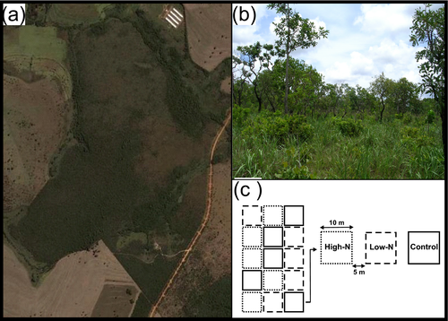

**Fig. 1**

(a) Aerial view of the study area, (b) view of the cerrado open savanna vegetation and (c) diagram of the experimental plots where nitrogen levels were manipulated.

### Litter decomposition experiment

We used these plots to conduct a litter decomposition experiment in each of three consecutive rainy seasons: November–March of 2009–2010, 2010–2011, and 2011–2012. We conducted the decomposition incubations during the rainy season because this is when most decomposition and mineralisation takes place in the Cerrado (Oliva *et al*. 1993; Nardoto & Bustamante 2003; Silva 2009). We conducted our experiments using litter of the perennial bunchgrass *Tristachya leiostachya* Nees (Poaceae); this species is native to the Cerrado, geographically widespread, and often locally dominant. In our field sites, this species represents ~57% of the above-ground biomass (E. M. B. 2011. unpubl. data).

We manually collected the litter for use in each year’s experiment in September. The litter was then dried to a constant mass at 55°C, after which we filled 225 decomposition bags: 75 bags with litter collected in ‘high-N addition’ plots, 75 bags with litter collected in ‘low-N addition’ plots, and 75 bags with litter collected in ‘control’ plots. The bags were 20 × 24 cm and made from nylon mesh with 1 mm openings; each bag was filled with 10 g of grass litter. Five randomly selected bags of litter from each N addition treatment were then distributed to each plot. To estimate the amount of biomass lost in transit to the field, we made an additional 10 bags and weighed the amount of litter remaining in them upon arrival. On average, bags lost 0.200 g during transport.

As with previous studies conducted in our field sites (Silva and Vasconcelos 2011), we collected the bags after 100 days (i.e. the bags were placed in sites on 23 November and collected 1 March). We then removed, dried and weighed any litter remaining in the bags. We calculated the proportion of the initial biomass remaining after 100 days (after correcting the initial weight by deducting the average amount lost in transport from all bags). When reporting the results of the decomposition trials, we refer to the year in which the experiment was initiated.

### Litter N concentration

We also measured the concentration of nitrogen in litter produced by *T. leiostachya* Nees (Poaceae) (C<sub>4</sub>) growing in the plots under different levels of fertiliser addition. In September 2009, 2010 and 2011, we collected additional litter from 8 randomly selected plants in each plot, pooled into a composite sample, mixed and finely milled. The samples were then digested in concentrated sulphuric acid, following the Kjeldahl method (Claessen 1997). Two measurements of foliar N (g kg<sup>−1</sup>) were made per digest. All analyses were performed in the Soil Analysis Laboratory of the Universidade Federal de Uberlândia.

### Soil sampling and ammonium determination

In March 2012, we assessed the amount of ammonium () in the soil. We collected the top 10 cm of soil from four cores in each plot (*N* = 60 cores total). These cores were immediately transported at 4°C to the Universidade Federal de Uberlândia for analysis. A portion of each sample was sieved (<4 mm), and its moisture content was determined by weighing before and after drying for 48 h at 105°C. We then incubated 5 g of soil in 10 mL of citrate buffer (pH 6.7) and after mixing for 30 min (Guan 1986). The amount of in each of the four samples collected per plot was determined using Uréia 500 Doles kits without adding 10% urea following the manufacturer’s guidelines (DOLLES, Brasil). The absorbance of the sample was determined by spectrophotometer at 600 nm (Model Biomate 3).

### Microbial activity

We also used the same soil cores used to assess the amount of ammonium () in the soil to measure proxies for microbial activity and abundance: basal soil respiration (i.e. the release of CO<sub>2</sub> by microorganisms resulting from the oxidation of organic matter), microbial carbon biomass in the soil (after macrofauna and roots have been removed; (Araújo & Monteiro 2007), the microbial community’s efficiency of incorporating carbon (i.e. the metabolic quotient, *q*CO<sub>2</sub>), and the activity of two enzymes involved in decomposition – β-glycosidase and urease (Nannipieri *et al*. 1980; Pajares *et al*. 2011). All four parameters shown can be altered by nitrogen enrichment (Zeglin *et al*. 2007; Janssens *et al*. 2010; Lv *et al*. 2013; Xu *et al*. 2016) and exhibit generally a positive relationship with litter decomposition (Alvarez & Guerrero 2000; Sinsabaugh *et al*. 2002; Allison *et al*. 2013; Lv *et al*. 2013).

To measure soil respiration, we used 100 g soil from each core collected separately in each plot (Stotzky 1965). The soil was placed in a glass vial (500 mL) and incubated for 28 days after placing 10 mL of 1 mol L<sup>−1</sup> NaOH in a vial on the surface of the sample to absorb the released CO<sub>2</sub>. Soil respiration was estimated by measuring the amount of CO<sub>2</sub> released 3, 10, 14, 21 and 28 days after the incubation. The C–CO<sub>2</sub> collected in the alkaline solution was determined by titration of residual NaOH with chloride acid (0.25 mol L<sup>−1</sup>) after the addition of 2.5 mL of BaCl<sub>2</sub>·2H<sub>2</sub>O (1 mol L<sup>−1</sup>) and phenolphthalein indicator. The C–CO<sub>2</sub> produced was expressed in mg C–CO<sub>2</sub> kg<sup>−1</sup> dry soil (Stotzky 1965). We measured the soil microbial carbon biomass (MCB) in each core using the irradiation-extraction method using microwave radiation (Ferreira *et al*. 2000). Differences in C concentration between irradiated and non-irradiated extract were used to determine MBC (Vance *et al*. 1987). The results were expressed in mg C kg<sup>−1</sup> dry soil. Metabolic quotient (*q*CO<sub>2</sub>) was then calculated as the ratio of basal respiration (CO<sub>2</sub> released) to C from the microbial biomass (Anderson & Domsch 1978).

Finally, we measured the activity of extracellular β-glycosidase by incubating 1 g of soil (Taylor *et al*. 2002) using *P*-nitrophenyl-β-d-glucopyranoside (PNG) as a substrate with a universal modified buffer with pH = 6.0. The product of the reaction, *p-nitrophenol* (PNP), was determined with spectrophotometer at 464 nm, and the results were expressed as µg p-NP g of dry soil h<sup>−1</sup>. We measured urease activity in each core with Guan’s method (1986), in which 5 g of soil are incubated for 3 h at 37ºC with 5 mL of 10% urea and 5 mL of citrate buffer (pH = 6.7). We determined the amount of ammonium released using Uréia 500 kits and a spectrophotometer at 600 nm following the manufacturer’s guidelines (DOLLES, Brasil). The results were expressed as µg N– g of dry soil h<sup>−1</sup>.

### Statistical analysis

We used split-plot analysis of variance (anova) to determine how N fertilisation influenced litter decomposition (Ellison & Gotelli 2004). The main effects were litter origin (i.e. high-N, low-N, or control plots) and litter destination (i.e. high-N, low-N, or control plots); we also included the litter origin × litter destination interaction. Data on the proportion of litter biomass remaining were logit-transformed prior to analysis (Warton & Hui 2011); separate analyses were conducted for each year of the experiment. We used nested anova to test how N fertilisation affect N litter concentration. Levels of N addition where the litter was collected (litter origin) and the year of litter harvested were fixed effects, with the two measurements of each composite nested within the plot in which the litter was collected (note that we did not use repeated measures anova because we did not necessarily sample the same individual plant each year). We also used nested anova to test for effects of N addition on soil ammonium, soil respiration, microbial biomass carbon, *q*CO<sub>2</sub>, β-glucosidase and urease activity. Separate analyses were performed for each parameter, with the four cores nested within the plot in which they were collected. Values for *q*CO<sub>2</sub>, soil respiration, MBC and were log-transformed prior to the analyses. All analyses were performed in the R statistical programming language (R Core Team 2017).

## Results

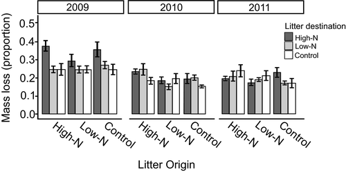

**Fig. 2**

The decomposition of *Tristachya leiostachya* litter harvested from plants grown in one of three N addition treatments (litter origin: high N, low N, control) and then transplanted to each of the three N addition treatments (litter destination: high N, low N, control). The experiment was repeated in three consecutive years; values of the *Y*-axis represent the proportion of the litter mass lost (±SE) after 100 days. In 2009: D = *, LO = NS, D*x*LO = NS; in 2010: D = NS, LO = *, D*x*LO = NS; in 2011: D = NS, LO = NS, D*x*LO = NS. Asterisk (*) indicates significant effect (*P* ≤ 0.05), D, destination; LO, litter origin and NS, not significant.

The concentration of nitrogen in litter differed significantly among treatments (Fig. 3). Litter collected in plots receiving high-N addition had a litter N concentration 12–17% higher than litter collected in low-N or control plots (*F*<sub>2,79</sub> = 11.33; *P* < 0.0001, Appendix S3). There was significant interannual variation (*F*<sub>2,79</sub> = 9.92; *P* = 0.0001), with the concentration of N in litter 6–12% higher in 2009 than in 2010 or 2011. However, there was no significant Treatment × Year interaction (Appendix S3).

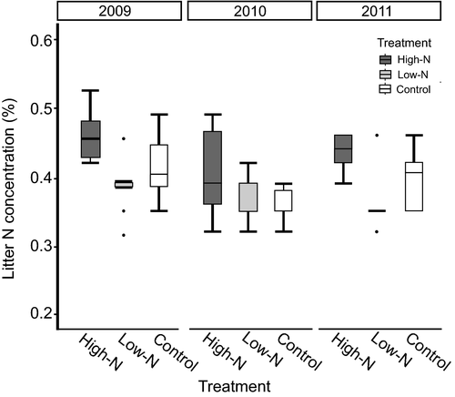

**Fig. 3**

In 2012, 4 years after the beginning of the fertilisation experiment, the concentration of ammonium in soil did not differ between plots receiving N addition and control plots (*F*<sub>2,12</sub> = 1.57; *P* = 0.25, Fig. 4d; Appendix S4). In addition, there was no difference among treatments in rates of soil respiration, microbial biomass carbon, qCO<sub>2</sub>, β-glucosidase or urease (Fig. 4a–f; Appendix S4).

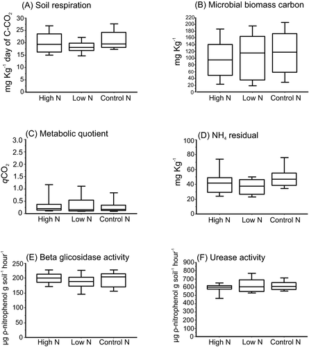

**Fig. 4**

## Discussion

Nitrogen enrichment is predicted to accelerate the decomposition of plant litter by increasing its N concentrations, allowing for increased microbial activity, or both (Chapin *et al*. 2011). Our experimental results indicate that in some years nitrogen enrichment can influence the process of litter decay, but the mechanisms by which it does so can vary temporally. We expected that litter both collected and incubated in plots receiving the highest level of nitrogen addition would have the highest rate of decomposition, but this was only observed in the first year of our experiment. The precise mechanisms responsible for the interannual variation in decomposition are unclear. However, the higher decomposition rates in 2009 compared with 2010 and 2011 could be related to higher precipitation (745.2 mm vs. 534 mm and 652.3 mm, respectively; Appendix S1).

The variable effects of fertilisation on decomposition are especially surprising in light of the generally positive correlation between the concentration of nitrogen in litter and the rate at which it decomposes (Aber & Melillo 1982; Melillo *et al*. 1982; Hobbie 2005; Knorr *et al*. 2005; Zhang *et al*. 2008). Although litter from N addition plots had a higher N concentration in all years of our experiment, we found no evidence for such consistent effects – in fact, litter from plots to which we experimentally added the most nitrogen only decomposed most rapidly in the second year, despite consistently having the highest N concentration.

We suggest the lack of an apparent relationship between litter N concentration and decomposition rate could be due to the lower precipitation in years 2 and 3 of our experiment. At the global scale, environmental characteristics – primarily rainfall and temperature – control decomposition rates, but decomposer agents and litter quality playing a secondary modulating role (Lavelle *et al*. 1993; Coûteaux *et al*. 1995). In the Cerrado region, litter decomposition occurs primarily during the rainy season because only then is the moisture deficit needed to stimulate microbial activity in the soil overcome (Coûteaux *et al*. 1995). It could be that precipitation in years 2 and 3 was below threshold necessary for microbial activity to be the primary factor driving decomposition, with litter quality instead becoming the primary modulating factor. In essence, variation in precipitation could have inverted the order of the factors controlling decomposition (sensu Berg et al. 1993).

Our results are also consistent with those of previous studies showing only limited enhancement of decomposition despite the sensitivity of tropical microbial communities to nitrogen enrichment (Cusack *et al*. 2011; Powers *et al*. 2015). It is important to point out, however, that we were only able to measure proxies for microbiological activity and the amount of soil in the last year of the litter decomposition experiment (2011), but based on previous studies we expected that the chronic addition of nitrogen to the soil would favour the increased activity and abundance of soil microorganisms (Waldrop *et al*. 2004; Grandy *et al*. 2008). However, we found no difference between N addition treatments in any of the variables we measured, which may be one reason why there also no difference in 2010 and 2011 in the rate of decomposition among experimental treatments. At the factors that could explain the lack of an effect of N addition on microbial activity at the end of experiment (2012) is probably limitation water (lower precipitation) that led to the limitation by other nutrient than nitrogen, as phosphorus (P). In year 1, the higher precipitation can have increased amount of P in the soil by the leaching process from the litter. On the other hand, the lower precipitation observed in years 2 and 3 did not provide enough phosphorus to meet the soil microorganism demand. Co-limitation of N and P is a common situation in terrestrial ecosystems, and it was widely discussed in the work of Elser *et al*. (2007). For instance, some studies on the nutritional deficiencies of Oxisols concluded that P is the most limiting nutrient in the soil microbial activity due to its adsorption and consequent immobilisation by Fe and Al sesquioxides (Ferreira *et al*. 2008; Cleveland *et al*. 2002). Although our experiment did not have a P-addition treatment, we also have previously shown the growth and reproduction of our focal species are co-limited by N and P in this site (Copeland *et al*. 2012). Thus, if nutrients (especially N and P) were available for longer, decomposers would spend less energy on nutrient acquisition and invest more energy in enzymes that degrade cellulose, hemicellulose and lignin (Weedon *et al*. 2009). This could indicate that nitrogen addition would only accelerate decomposition in combination with phosphorous (Kozovits *et al*. 2007; Jacobson *et al*. 2011), which is also found at extremely low levels in these highly weathered soils (Haridasan 2001) and limit the microbial community (Weedon *et al*. 2009). Interestingly, these results are in line with those of the few prior studies of decomposition in the Cerrado (Kozovits *et al*. 2007; Jacobson *et al*. 2011).

In many regions of the world, including Brazil, atmospheric N deposition is on the rise (Ackerman *et al*. 2019). The results of our experiment – which was based on realistic ‘optimistic’ and ‘pessimistic’ predictions of N enrichment for the Cerrado – suggest that such nitrogen addition can indeed influence patterns of litter decomposition, albeit only under the most pessimistic scenario (50 kg ha<sup>−1</sup> year<sup>−1</sup>). However, they also suggest that the effects can be temporally variable in magnitude and direction. This is because mechanisms regulating decomposition in these ecosystems can be influenced by variation in annual precipitation. The predicted changes in precipitation in Brazil are significant (IPCC 2007) with a predicted decrease of 20–50% in the central and southern parts of the Cerrado (Marengo *et al*. 2009). Predicting the consequences of accelerating nitrogen deposition on nutrient cycling and ecosystem function, especially in Neotropical savannas undergoing climate change, will require models and experiments that consider potential synergies with changing precipitation regimes – especially in light of the emerging consensus that multiple factors interact to shape decomposition rates (Zhang *et al*. 2008).

## Acknowledgements

We thank Fernando Pedroni, Ana Silvia F. P. Moreira, Marcelo Henrique O. Pinheiro and the reviewers and editors of this paper for their helpful comments and suggestions We also thank the Universidade Federal de Uberlândia for providing logistical support and Suelen M. Oliveira for feedback, assistance in the field and in the laboratory. Financial support was provided by grants from the US National Science Foundation (DEB-0542287) and David and Lucile Packard Foundation to EMB, by grants from the Brazilian Council of Research (CNPq grants # 403733/2012-0 and 441225/2016-0) and Fapemig (APQ-03202-13) to HLV, a CAPES Special Visiting Researcher Fellowship (Grant AUXPE-PVE-0205/2013) to EMB, and Fellowships from CAPES to LVBS. The data used in this article and code for their analysis are archived at Zenodo.org ([doi: 10.5281/zenodo.3952607](https://doi.org/10.5281/zenodo.3952607)).

## Author contributions

**Laura Vivian Barbosa Silva:** Conceptualization (lead); data curation (lead); formal analysis (lead); investigation (lead); project administration (lead); writing-original draft (lead); writing-review & editing (lead). **Heraldo L. Vasconcelos:** Conceptualization (supporting); data curation (supporting); formal analysis (supporting); funding acquisition (lead); investigation (supporting); methodology (supporting); project administration (supporting); resources (lead); writing-original draft (supporting); writing-review & editing (supporting). **Michelle C. Mack:** Conceptualization (supporting); methodology (supporting); project administration (supporting); visualization (supporting); writing-review & editing (supporting). **Adão de Siqueira Ferreira:** Conceptualization (equal); data curation (lead); formal analysis (lead); funding acquisition (lead); investigation (supporting); methodology (lead); project administration (lead); visualization (supporting); writing-review & editing (supporting). **Emilio M. Bruna:** Conceptualization (lead); data curation (lead); formal analysis (lead); funding acquisition (lead); investigation (supporting); methodology (supporting); project administration (lead); resources (lead); supervision (lead); visualization (lead); writing-original draft (lead); writing-review & editing (lead).

## Citing Literature

[Volume45, Issue8](https://onlinelibrary.wiley.com/toc/14429993/2020/45/8)

December 2020

Pages 1093-1102